# VARIABLES ALEATORIAS

$$\begin{cases}
A & 100\\
S & 50
\end{cases}$$

# tipos

Existen tres tipos y son:

- Continuas
- Disctretas
- Mixtas

Las variables aleatorias continuas tiene un numero infinito de elementyop,mientrs que las discretas tienen un numero finito contable de elementos. La variable mixta, es un a combinacion de variable aleatoria continua y discrreta.

# distribuiciones

Las var5iables aleatorias se pueden caracterizar mediante dos funciones; la funcion de distribuicion acumulativa, $F_X(x)$ y la funcion de densidad. $f_x(x)$.

## la funcion de distribuuicion acumulativa

La funcion de distribuicion acumulativa se define como:
$$F_X(x) = P_r\{X \le x\}$$
Ademas, cumple con las siguientes propiedades
$$O\le F_X(x) \le 1\\
\mbox{Si}\; a < b, F_X(a) \le F_X(b)\\
F_X(\infty) = 1$$
En `R` , generamos distribuiciones usando los comandos :

- `binom` variable aleatoria binomial
- `norm` variable aleatoria normal o Gaussiana
- `pois` variable aleatoria Poison
- `exp` variable aleatoria exponencial

y anteponiendole un `p`, por ejemplo:

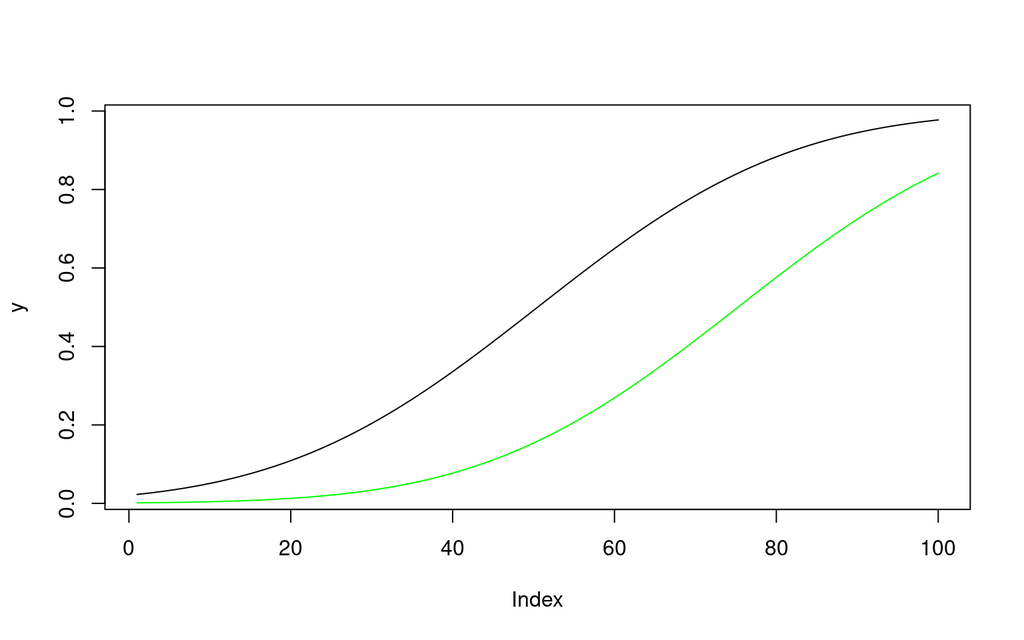

```r
 x <- seq(-4,4, length=100)
 y <- pnorm(x, mean=0, sd =2)
 y1 <- pnorm(x, mean=2, sd=2)
 plot(y, type= "l")
 lines(y1, col="green")
```

## La funcion de densidad de probabilidades (PDF)

La funcuion de densidad de probabilidad, $f_X(x)$, se define como
$$f_X(x) = \frac{d} {dx}\left\{ F_X(x)\right\}$$
De la misma manera que lña distribuicion ($F_X(x)$), la densidad ($f_X(x)$), se puede generar mediante los comando `binom`, `norm`, `exp`, etc, anteponiendo una `d`, por ejemplo `dbinom,`dexp`, etc.

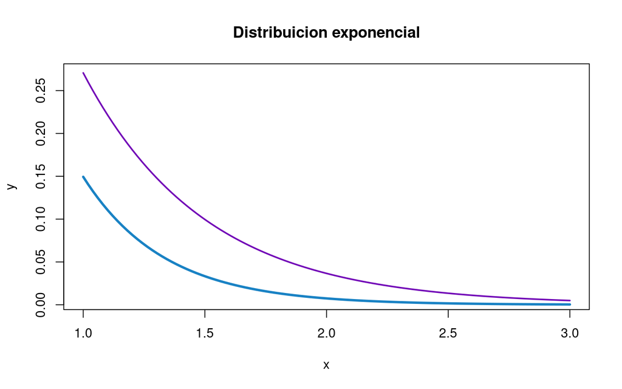

```r
x <- seq(1,3, length=100)
y <- dexp(x, rate=2)
y1 <- dexp(x, rate=3)
plot(x,y, type = "l", col="#7209b7", lwd=2, main="Distribuicion exponencial")
lines(x,y1, col="#1982c4", lwd=3)
```

## Generacion de valores de las variables aleatorias

Para generar valores de una distribuicion usando `R`, anteponemos la letra `r`antes de cualquier nombre de distribuicion o densidad, por ejemplo `rbinom`, `rnorm`, etc.

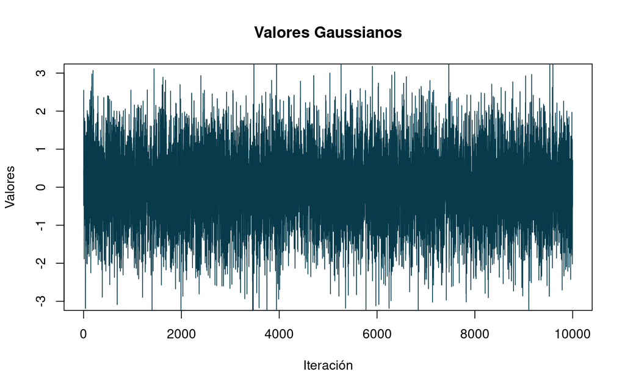

```r
 valores <- rnorm(10000)
uniforme <- runif(10000 -1,1)
plot(uniforme, type="l", col="#9bf6ff", main="Valores Gaussianos", xlab="Iteración",
ylab="Valores",ylim =c(-3,3))
lines(valores, col ="#073b4c")
```

## Momentos de las funciones de densidad

Cacartyerizan la posicion, ancho, asimetria y picudez de una densidad $f_X(x)$. Entre los momentos mas conocidos:

- Media
- Varianza
- Asimetria

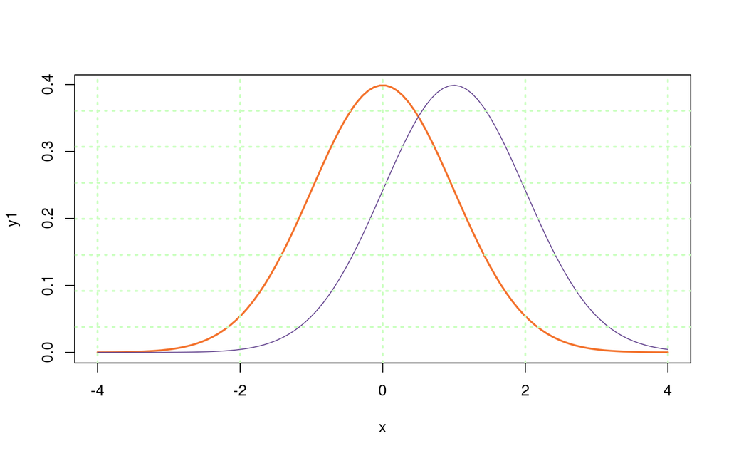

```r
x <- seq(-4,4,length=100)
y1 <- dnorm(x, mean=0, sd=1)
y2 <- dnorm(x, mean=1, sd=1)
plot(x,y1, type="l" , col="#f3722c", lwd=2 )
lines(x,y2, col="#6a4c93")
grid(col = "#caffbf" ,lwd=2,lty = "dotted", ny=8)
```

Para la varianza se tiene:

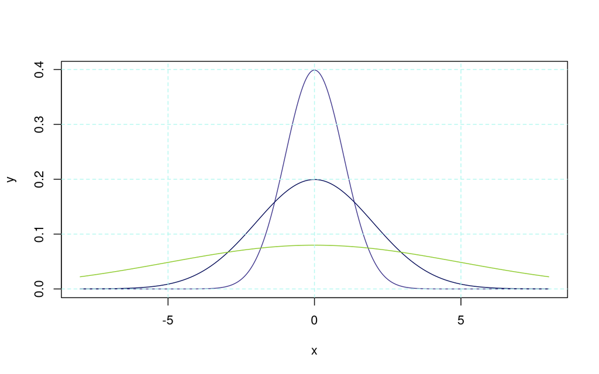

```r
 x <- seq(-8,8,length=1000)
 y <- dnorm(x,mean=0, sd=1)
 y2 <- dnorm(x, sd=2)
 y3 <- dnorm(x, sd=5)
 plot(x,y, type="l", col="#3d348b")
 lines(x,y2, col="#000B58")
 lines(x,y3, col="#8ac926")
 grid(col="#b2f7ef", lty="dashed")
```

### Momentos e el origen

Los momentos en el origen de orden $n$ se definen como:
$$\mathbb{E}\left\{X^n\right\} =
\begin{cases}
\sum_j{X_j^n P(X=x_j)} & \mbox{si es discreto}\\
\int_{\mathbb{R}}{x^nf_X(x)\ dx} & \mbox{si es continuo}
\end{cases}$$
### Momentos centrales

Los momentos cebntrales se definen como:

$$\mathbb{E}\left\{(X-\mu)^n\right\} =
\begin{cases}
\sum_j{(x_j-\mu)^n P(X=x_j)} & \mbox{si es discreto}\\
\int_{\mathbb{R}}{(x-\mu)^nf_X(x)\ dx} & \mbox{si es continuo}
\end{cases}$$

Donde $\mu$ es el momento con respecto al oriegn de orden $l$. Para $n=2$, tenemos la varianza.

```r
 set.seed(100)
x <-rnorm(n =1000000)
mean(x)
```

```
## [1] 0.001420706
```

```r
var(x)
```

```
## [1] 0.9982819
```

```r
sd(x)
```

```
## [1] 0.9991406
```

### La variable aleatoria exponencial.

Está definida por un único parámetro, λ (lambda), conocido como el **parámetro de tasa** (rate parameter), que representa el número promedio de eventos que ocurren por unidad de tiempo.

# Funcion de densidad de probabilidad (PDF)

La PDF nos da la probabilidad relativa de que el vento ocurra en un momento exacto $x$. Para una variable aleatoria exponencial $X{\sim Exp (\lambda)}$ su PDF es:

$$f(x; \lambda) = \begin{cases}
\lambda e^{-\lambda x} & \text{si } x \ge 0 \\
0 & \text{si } x < 0
\end{cases}$$

## Funcion de distribuición acumulada

La CDF nos da la probabilidad de que el evento ocurra en o antes de un tiempo $x$. Su formula es:
$$F(x; \lambda) = \begin{cases}
1 - e^{-\lambda x} & \text{si } x \ge 0 \\
0 & \text{si } x < 0
\end{cases}$$
Donde:

$x$ es el valor de la variable aleatoria (tiempo)